# Using the Bloomberg Terminal to Explore Stock Market Trends: An Analysis of Historical EPS Forecast Accuracy for All Firms in the 2019 S&P 500 Index

### by Marc Angelo Acebedo

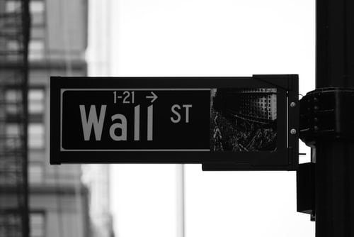

## Investigation Overview

> Through using Bloomberg Excel functions, I gathered the following 4 stock price data for all firms in the 2019 S&P Index from 1999 - 2019:
- Actual EPS
- Forecasted EPS
- EOD Price
- Forecasted EPS (made 3 months prior)

For a broad picture, I wanted to examine the accuracy between **forecasted EPS** to their corresponding **actual EPS** values.

## Dataset Overview

The main dataset, **features.csv**, consists of 167,660 entries with 5 columns.

The other dataset in question, **avgs.csv**, contains 52,015 with 5 columns.

> The quantitative values in this dataset consist of yearly, quarterly, and twenty-year *averages* extracted from the previous *features.csv* dataset.

Lastly, **firms.csv** assigns each firm abbreviation with firm ID as the primary key.

## Question 1

> Does average EPS prediction error depict any differences in trends among a yearly, quarterly, and full-term basis?

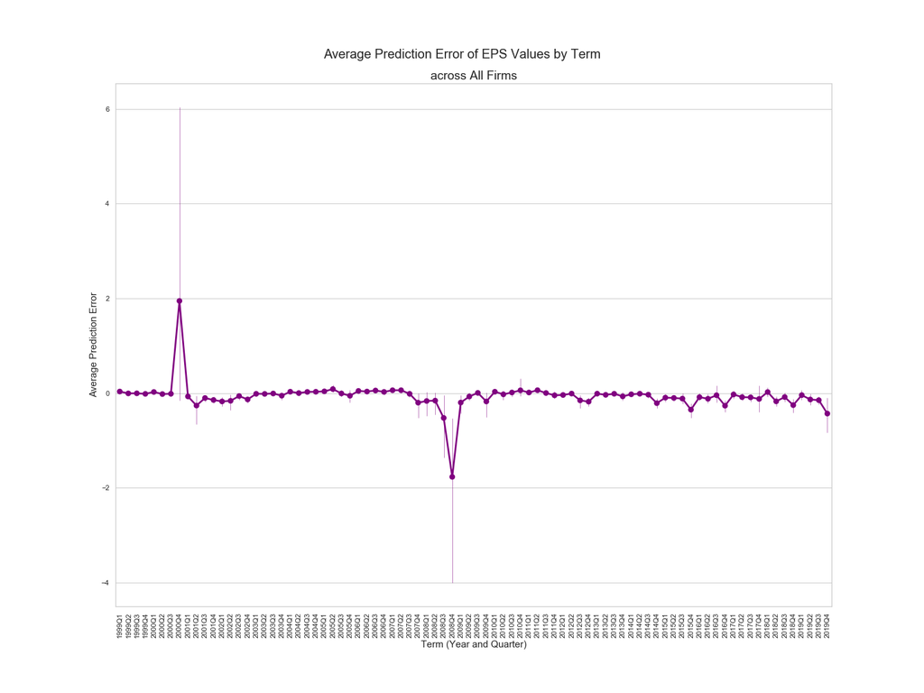

```python
Image(filename = PATH_BIVARIATE + 'features-act-fc-diffs-term.png')
```

**Observation 1:** Bloomberg forecasters were most **optimistic** in 2008Q4, and most **pessimistic** in 2000Q4.

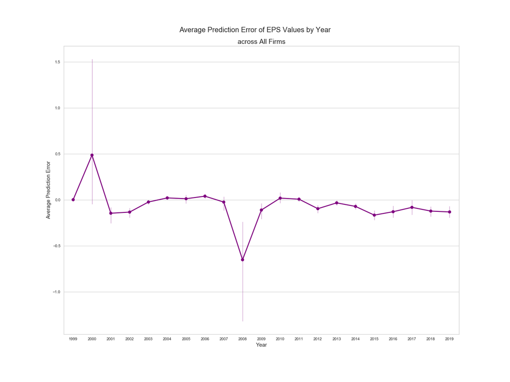

```python
Image(filename = PATH_BIVARIATE + 'features-act-fc-diffs-year.png')
```

**Observation 2:** Forecasters were most **optimistic** in 2008, and most **pessimistic** in 2000.

> This is consistent with the previous observation depicting EPS prediction error by full term, not by year.

- Stock Market Crash of 2008?

**Observation 4:** When ignoring the optimistic and pessimistic outliers, there is no slope.

> All average EPS prediction errors gather around 0.

**Observation 6:** The year 2008 shows one of the widest variances in average prediction errors, ranging from -0.25 to -1.5.

> This means that **outlier** Bloomberg EPS forecasts, on average, contain variety of data points that are far away from the mean. This means that the most "pessimistic" and "optimistic" forecasts contain a wider spread of data, and thus, are associated with forecasters making higher risks.

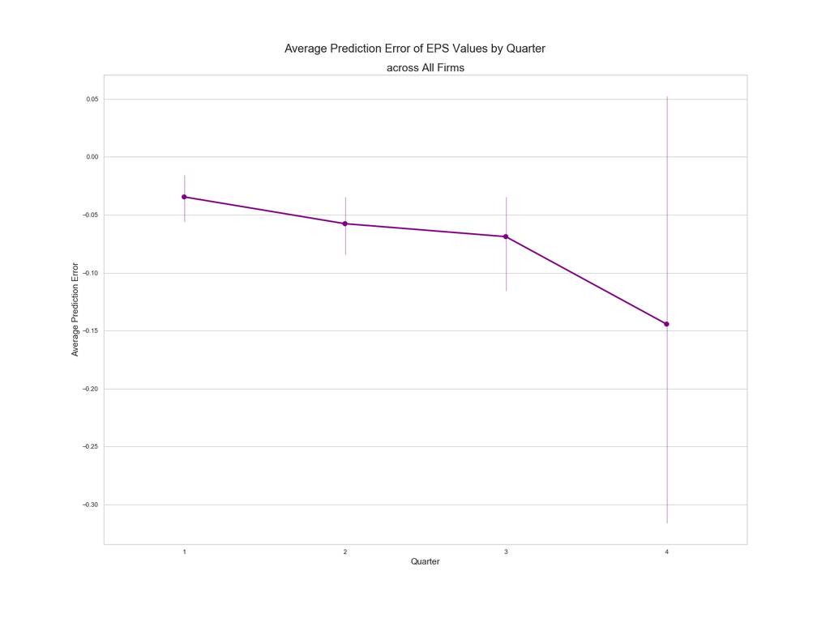

```python
Image(filename = PATH_BIVARIATE + 'features-act-fc-diffs-quarter.png')
```

**Observation 5:** The later the quarter, the more optimistic forecasters become in their predictions.

> Intuitively, this makes sense. As the familiarity of the year increases and stock market trends become more predictable, the more I conjecture that forecasters would become more confident in their EPS predictions.

**Observation 5a:** We only see a *predictable pattern* emerge when examining EPS prediction errors by a quarterly basis.

- pattern is *usually optimistic*
- outliers happen exclusively on Q4 of any given year.

## Question 2

> I generate naive EPS forecasts by calculating the rolling mean of the 2 actual EPS values from the past 2 quarters. How do my EPS forecasts compare to Bloomberg's EPS forecasts?

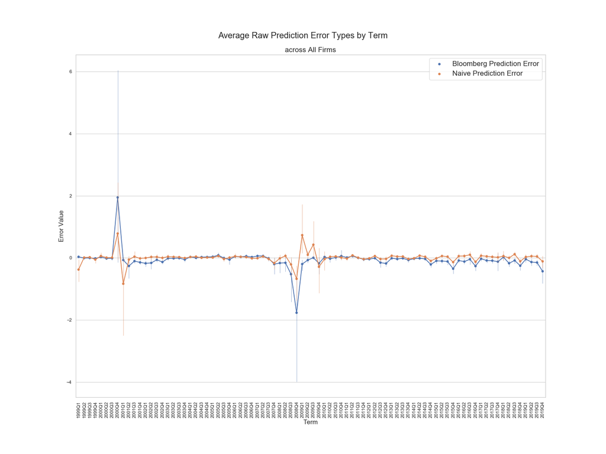

```python
Image(PATH_MULTIVARIATE + 'blmbrg-naive-pred-term.png')
```

**Observation 1:** There are 2 notable terms regarding Bloomberg EPS forecasts: 2008Q4 and 2000Q4. Bloomberg forecasters were overly *optimistic* in 2008Q4, while overly *pessimistic* in 2000Q4.

**Observation 2:** There are 4 notable terms regarding my naive EPS forecasts: 2000Q4, 2001Q, 2008Q4, and 2009Q1.

**Observation 3:** From 2012Q3 onwards, my average naive prediction errors stay closer to 0 than the Bloomberg prediction errors do.

> Average Bloomberg prediction errors tend to be *lesser* than the naive forecasts from that period, veering *away* from 0. This means that *in the more recent years since 2012, Bloomberg EPS forecasts were less accurate than my own naive forecasts.*

**Observation 4:** My average naive forecasts and Bloomberg forecasts both roughly "equalize", following the same trend "clustering" around 0, from 2003Q4 to 2007Q4.

**Observation 5:** Look at 2000Q4 and 2001Q4. In the former, my naive forecasts tend to be **overly pessimistic, then turn overly optimistic** in the quarter immediately after.

**Observation 6:** Look at 2008Q4 and 2009Q1, where the previous pattern is reversed. In the former, my naive forecasts tend to be **overly optimistic, then become overly pessimistic** in the quarter immediately after.

> Expanding from the previous 2 observations, it seems that my naive prediction errors change "mood" when entering a new year *from 2000 to 2001* and *2008 to 2009*.
- An interesting note: my naive forecasts spiked in pessimism during 2009Q1: only *right* before the Great Recession began to recover in June of 2009.
- Another interesting note: Bloomberg forecasters tended to be overly optimistic in their EPS forecasts during the "harder" years of the bear market.

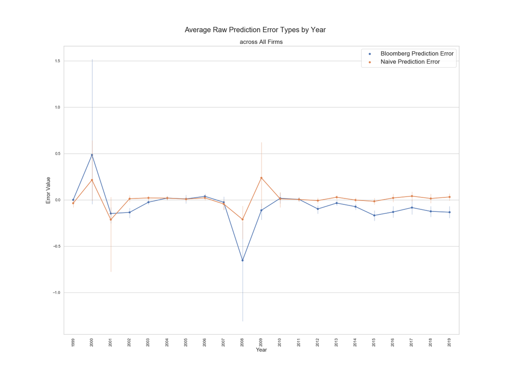

```python
Image(PATH_MULTIVARIATE + 'blmbrg-naive-pred-year.png')
```

**Observation 1:** The most notable years are 2008 and 2000.

- Bloomberg forecasters tended to be overly optimistic in 2008, and overly pessimistic in 2000.
- In both years, my average naive prediction errors tended to be a *better fit* than Bloomberg prediction errors, since they all tend to cluster around 0 while Bloomberg errors veer *far* away from 0.

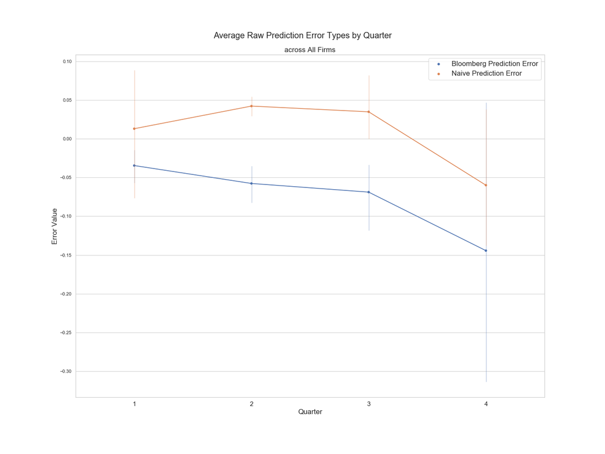

```python
Image(PATH_MULTIVARIATE + 'blmbrg-naive-pred-quarter.png')
```

**Observation 1:** Across *all quarters*, my naive forecasts have *always* tended to be a better fit than the Bloomberg EPS forecasts.

> A **key takeaway**: No matter what quarter, my naive forecast is *always* more reliable.

**Observation 2:** Bloomberg EPS forecasts tend to be more **optimistic** in **Q2** of any year, while my naive forecasts tend to be more **pessimistic** in **Q2** of any year.

> In Q2, the average prediction errors for both Bloomberg and naive forecasts "split up" into separate directions.

**Observation 3:** In **Q4** across all years, both forecast types tended to be more **optimistic.** This makes intuitive sense.

> What if we removed outliers?

### Now let's look at a random selection of 5 firms from our data pool.

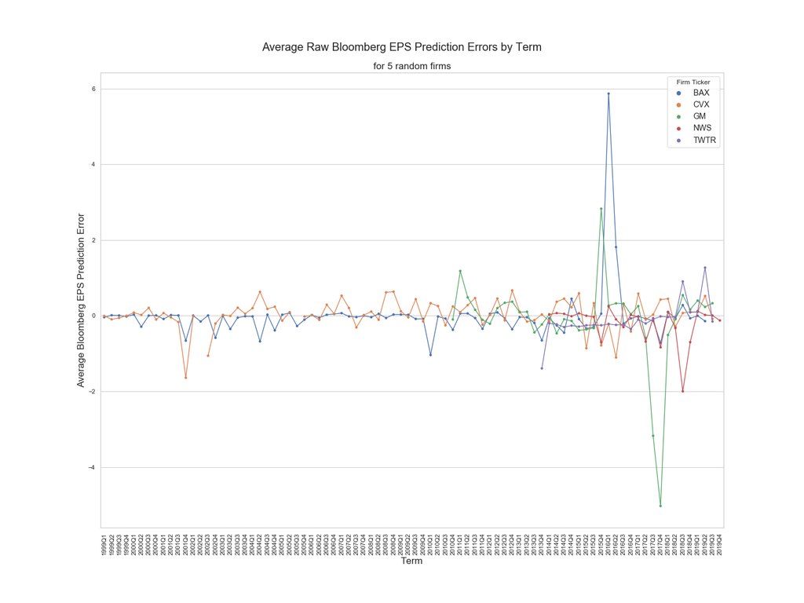

```python
Image(PATH_MULTIVARIATE + 'blmbrg-pred-error-term.png')
```

**Observation 1:** To summarize with three words: for any 5 random firms, average Bloomberg EPS prediction error trends are *scattered*, *inconsistent*, and *erratic*.

**Observation 2:** No outliers appear during 2000Q4 or 2008Q4.

> This is a key takeaway, since a few outlying prediction errors DO affect the overall prediction error trends during these 2 terms.

**Observation 3:** One notable outlier occurs at 2017Q4, where 3 random firms consistently show an average overly optimistic EPS forecast from Bloomberg.: GM, NWS, and TWTR.

**Observation 4:** Another notable outlier occurs at *2016Q1*, where **BAX** is an outlying firm showcasing *overly pessimistic* EPS forecasts from Bloomberg.

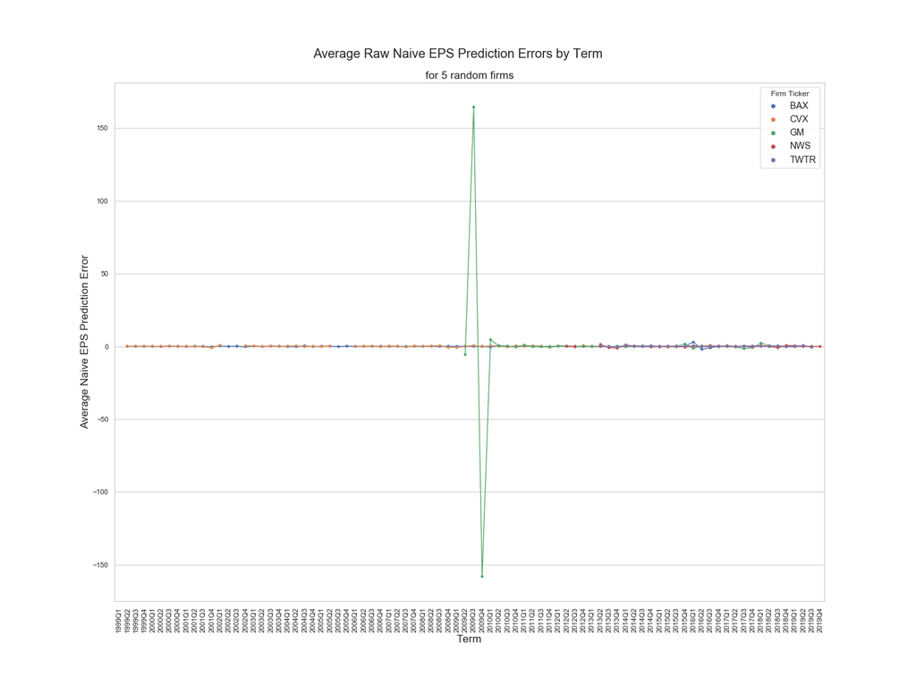

```python
Image(PATH_MULTIVARIATE + 'naive-pred-error-term.png')
```

**Observation 3:** For Bloomberg forecasts, GM actually shows a better fit than my naive forecasts.

**Observation 4:** This graph depicts a much *larger* scale; the Bloomberg one ranges from -6 to 6 on the y-axis, while my naive one ranges from -150 to 170 on the y-axis.

- This means that for the 5 random firms selected, my naive forecasts tended to be a better fit.
- But whenever an outlying firm is depicted, those outlying values stray *further* from 0, which means my naive forecasts were a worse fit.

> To summarize: my naive forecasts are usually more reliable than the Bloomberg forecasts, ONLY when outliers are not present.

## Question 3:

> What differences/similarities emerge when analyzing the prediction error and percentage error of EPS forecasts?

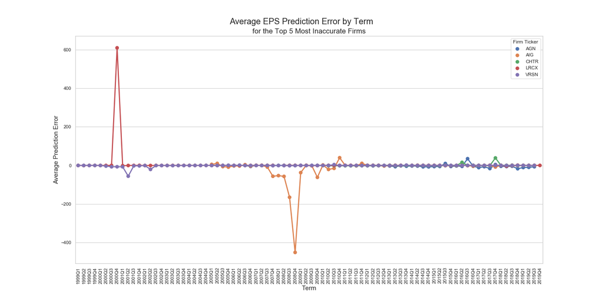

```python
Image(PATH_MULTIVARIATE + 'features-perror-term-firm.png')
```

**Observation 1:** The top 5 most inaccurate firm tickers in terms of absolute *prediction error* are AGN, AIG, CHTR, LRCX, and VRSN.

> These stand for Allergan plc, American International Group Inc, Charter Communications Inc, Lam Research Corporation, and Verisign.

**Observation 1a:** The most notable outlier is **AIG.**

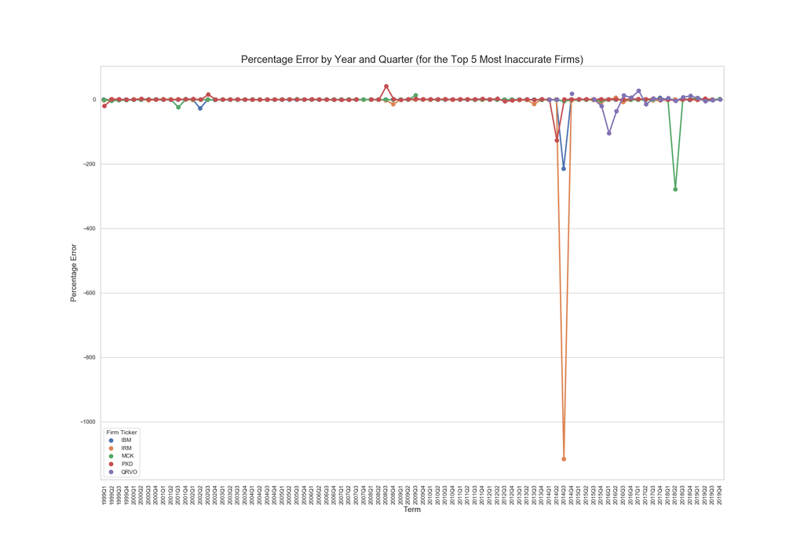

```python
Image(PATH_MULTIVARIATE + 'pct-firm-term.png')
```

**Observation 2:** The top 5 most inaccurate firm tickers in terms of absolute *percentage error* are IBM, IRM, MCK, PXD, and QRVO.

> These stand for IBM Common Stock, Iron Mountain Inc., McKesson Corporation, Pioneer Natural Resources, and Qorvo Inc.

**Observation 2a:** The most notable outlier is **IRM.**

- Percentage error of over -1000 for EPS in the term 2014Q3.
- Outliers only start appearing in the year 2014 onward.

**Observation 3:** For *prediction errors*, Bloomberg forecasters, on average, are likely to be more inaccurate in Q4 of any given year.

> The top 5 most inaccurate firms by prediction error display relatively low average prediction errors until Q4, when both LRCX and AIG "branch off" into opposite directions.

**Observation 4:** For *percentage errors*, EPS forecasts have *become more inaccurate in the more recent terms*, starting from 2014Q3.

> This observation is consistent with the observations made in the quarterly and yearly stripplots below.

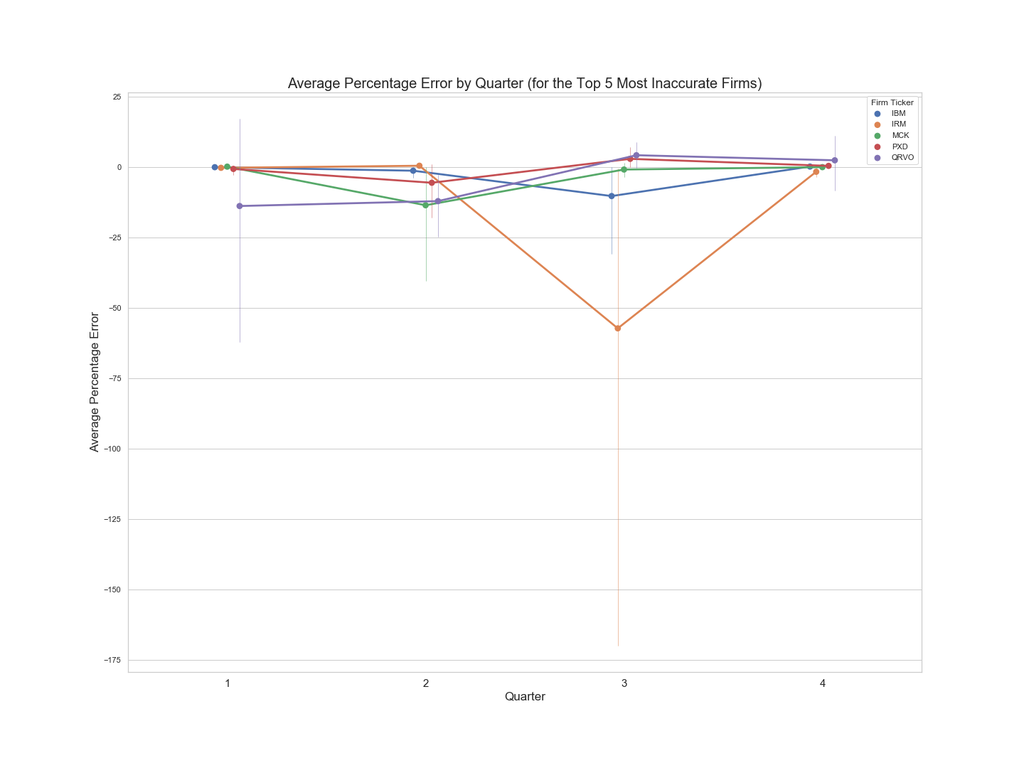

```python
Image(PATH_MULTIVARIATE + 'pct-firm-quarter.png')
```

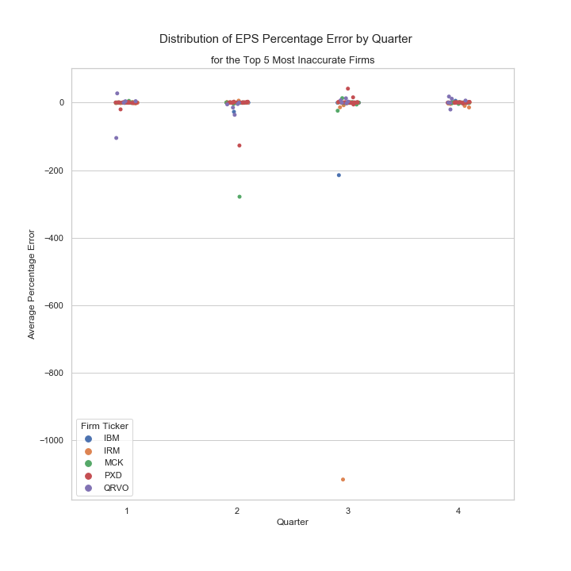

```python
Image(PATH_MULTIVARIATE + 'pct-firm-quarter-top-strip.png')
```

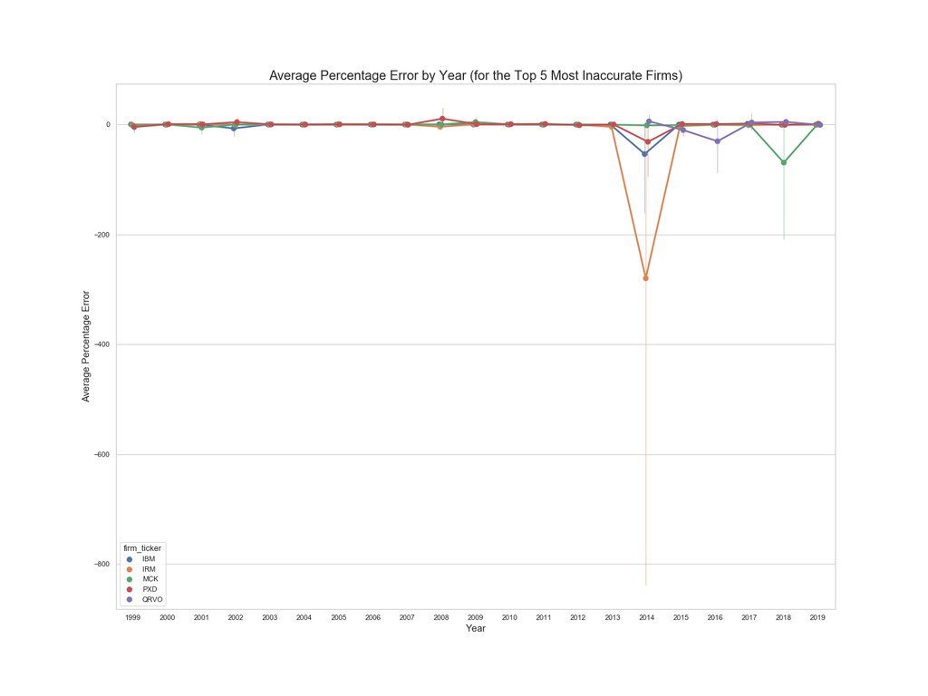

```python
Image(PATH_MULTIVARIATE + 'pct-firm-year-top.png')
```

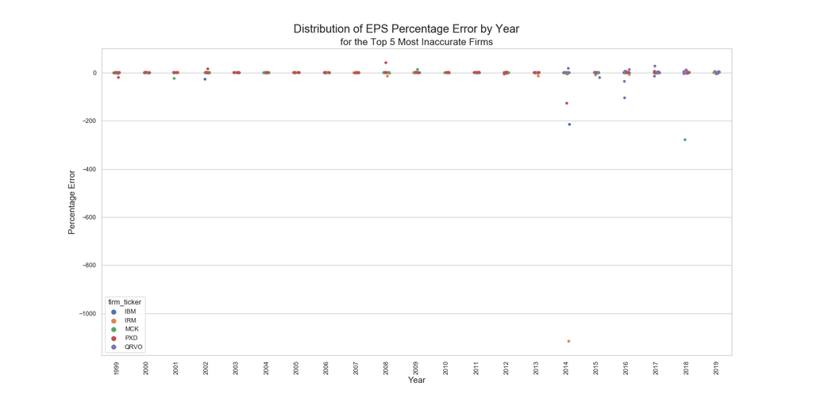

```python
Image(PATH_MULTIVARIATE + 'pct-firm-year-top-strip.png')
```

**Note**: prediction error charts are *not* consistent with the average percentage error charts.

- Percentage error tells you how "big" your errors are
- Prediction error simply tells you how "close" your prediction error was to the accepted value.

## Question 4:

> How do my naive RMSE values compare to Bloomberg RMSE when accounting for EPS forecasts? For what percentage of firms does my naive RMSE beat Bloomberg’s RMSE?

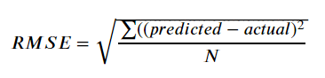

```python
Image(PATH_MISC + 'rmse.png')
```

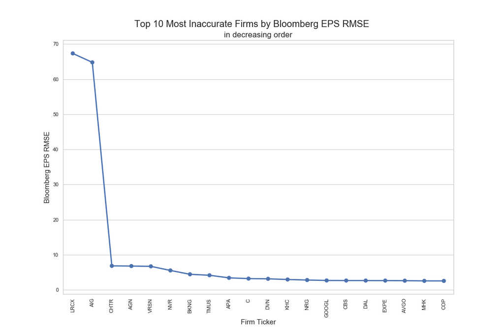

```python
Image(PATH_BIVARIATE + 'rmse-bloomberg.png')
```

**Observation 1:** The 2 most notable outlier firm tickers are LCRX and AIG, with values at approximately 68 and 65 respectively.

**Observation 2:** After AIG and LCRX, RMSE values for the next most inaccurate firms (in descending order) follow a more stable pattern, with a decreasing negative linear trend approaching 0.

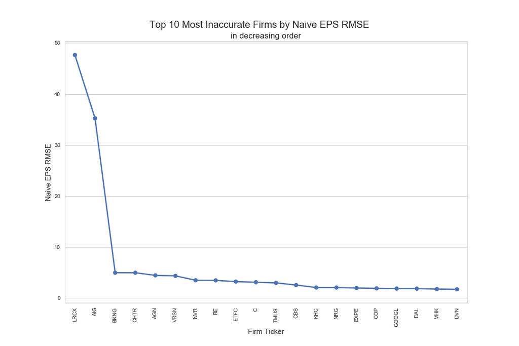

```python
Image(PATH_BIVARIATE + 'rmse-naive.png')
```

**Observation 1:** The 2 most notable outlier firm tickers are LCRX and AIG, with values at approximately 48 and 36 respectively.

> These firm tickers for Naive EPS RMSE are consistent with the outlying firm tickers for the Bloomberg EPS RMSE.

**Observation 2:** After AIG and LCRX, RMSE values for the next most inaccurate firms (in descending order) follow a more stable pattern, with a decreasing negative linear trend approaching 0.

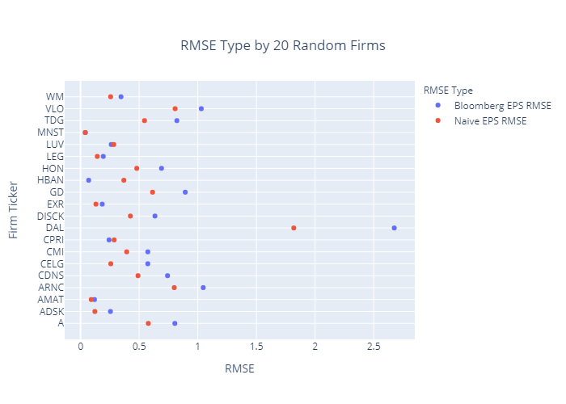

```python
Image(PATH_MULTIVARIATE + 'rmse-blmbrg-naive.png')
```

**Observation 1:** Out of the 20 randomly selected firm tickers, WM, VLO, TDG, MNST, LEG, HON, GD, EXR, DISCK, DAL, CMI, CELG, CDNS, ARNC, AMAT, ADSK, and A have a Bloomberg RMSE that is greater than my Naive RMSE.

> Those are 17 out of 20 firm tickers in total, where *my naive forecasts were a better fit than the Bloomberg forecasts.*

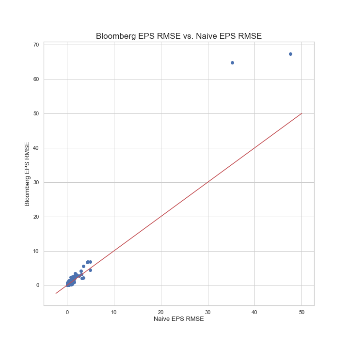

```python
Image(PATH_BIVARIATE + 'rmse-blmbrg-naive-outliers.png')
```

### All points above the red y = x line represent a Bloomberg EPS RMSE that is greater than my Naive EPS RMSE.

**Observation 1:** For the 2 outlying points, their Bloomberg RMSE is greater than my Naive RMSE.

This means that my naive EPS forecasts were a better fit for these 2 firm tickers than the Bloomberg forecasts.

- These 2 outlying points represent the firms LCRX and AIG.

**Observation 2:** When ignoring outliers, it's still hard to draw a conclusion based on the the ratio of points above the y = x vs below.

But by visualization alone, it seems that **more points are above the y = x line than below.**

### Let's remove outliers and zero in on the bulk of the data:

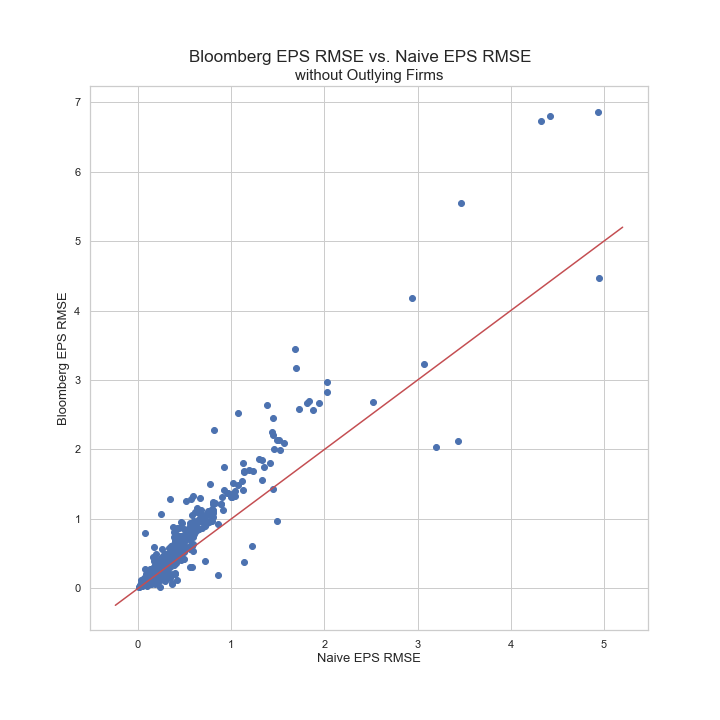

```python
Image(PATH_BIVARIATE + 'rmse-blmbrg-naive-no-outliers.png')
```

**Observation 1:** My previous estimation was correct.

There are, in fact, *more Bloomberg EPS RMSE values that are greater than my Naive EPS RMSE values* per firm. This means that for the bulk majority of the data, my naive forecasts were much *more* reliable than the Bloomberg EPS forecasts. This is a major takeaway.

**Observation 2:** Of all the RMSE values, *86.95% of my Naive EPS RMSE values are less than the Bloomberg EPS RMSE values.*

> For each firm, I subtracted their Naive RMSE from their respective Bloomberg RMSE. Any difference above 0 indicates that the Bloomberg RMSE was much larger. This percentage is consistent with the visual I produced.

## Question 5

> How do EOD prices trend across all firms from 1999 - 2019?

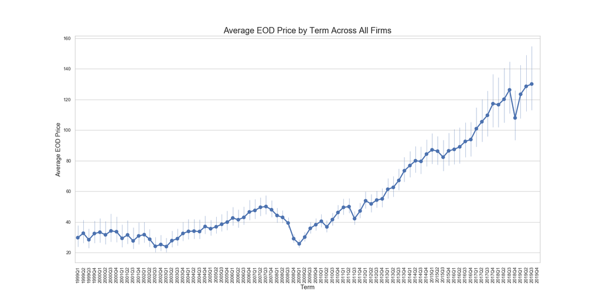

```python
Image(PATH_BIVARIATE + 'features-eod-term.png')
```

**Observation 1:** EOD prices "trough" from 2007 - 2009: the exact years of the Great Recession.

- A catastrophic bear market took hold in the USA between 2007 and 2009.
- In 2008, the S&P was down around -38%.
- In 2009, the S&P 500 Index made a speedy recovery, finishing at around 23%.

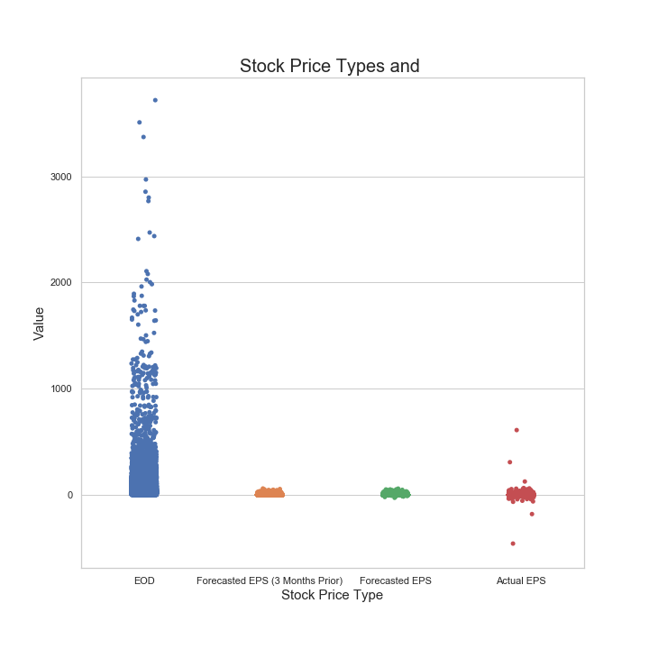

```python
Image(PATH_BIVARIATE + 'features-feature-value.png')
```

**Observation 2:** All patterns shown in the Actual vs. Forecasted pointplots are consistent with the EOD distribution shown in the above visual.